# Assignment 4

## Topic: ICA

## Machine Learning: Unsupervised Techniques, SS 2019

### Deadline Saturday, April 27th 2019, 24:00

Return this notebook with your code and answers.

# Exercise A

In this exercise we want to discuss certain theoretical basics of ICA in greater detail. An important aspect of ICA is concerned with measuring non-Gaussianity of random variables. Here we discuss one possible approach in this context that uses cumulants of random variables. These objects are in general defined as follows: for a real-valued random variable $X$ we consider the cumulant generating function $K_{X}$ given by $K_{X}(t)=\ln(\text{E}(e^{Xt}))$. The $n$-th order cumulant $\kappa_n(X)$ corresponding to $X$ is then defined as the $n$-th coefficient in the Taylor-series expansion for $K_{X}(t)$ near $0$, i.e. $K_{X}(t)=\sum_{n=1}^\infty \frac{\kappa_n( X) t^n}{n!}$, and thus $\kappa_n(X)=K_{X}^{(n)}(0)$ (the $n$-th derivative of $K_{X}(t)$ evaluated at $0$). We start by showing some important properties of cumulants, that make many calculations (especially regarding sums of independent random variables) easier compared to the use of moments. Let us try to get a better understanding about how these objects look like explicitely and can be computed in practice by deriving relations between moments and cumulants.

### Bonus Question 4.1 (10 Points):

This question is not mandatory, but you might get extra credits. It assumes basic familiarity with Taylor series.

Assume that $X$ is a centered real random variable, i.e. $\text{E}(X)=0$. Use $$ \text{E}(e^{tX})=\sum_{n=0}^\infty \text{E}(X^n) \frac{t^n}{n!} $$ and the Taylor series expansion of the logarithm near $1$, i.e.

$$ \ln(1+t)=\sum_{n=1}^\infty \frac{(-1)^{n+1} t^n}{n}=t-\frac{t^2}{2}+\frac{t^3}{3}\pm ... $$

to compute the first four cumulants in terms of the moments. As a result you should obtain $\kappa_1(X)=0$, $\kappa_2(X)=\text{E}(X^2)$, $\kappa_3(X)=\text{E}(X^3)$ and $\kappa_4(X)=\text{E}(X^4)-3(\text{E}(X^2))^2$.

Hint: You are only interested in an expansion up to order $4$, so you can drop all the higher order terms in all steps of your calculations!

- **TODO:** Markdown, Latex

### Question 4.2 (15 Points):

Next we are interested in computing the aforementioned cumulants for a standard normally distributed random variable $X \sim \mathcal{N}(0,1)$. By calculating the moments $\text{E}(X^3)$ and $\text{E}(X^4)$, confirm that $\kappa_3(X)=\kappa_4(X)=0$.

Hint: Recall that for a real-valued random variable $X$ with density $p(x)$, we have that $\text{E}(f(X))=\int_{-\infty}^{\infty} f(x)p(x) dx$ for any say "reasonable" function $f$. E.g. for $X \sim \mathcal{N}(0,1)$ one can calculate $\text{E}(X^2)=\int_{-\infty}^{\infty} x^2 \frac{1}{\sqrt{2 \pi}} e^{-\frac{x^2}{2}} dx$. You can assume that $\text{E}(X)=0$ and $\text{E}(X^2)=1$(this is basically contained in the definition of $X \sim \mathcal{N}(0,1)$). For $\text{E}(X^3)$ you can in principle avoid any calculations, if you use a clever argument regarding the structure of the integrand(keyword: even/odd functions). For $\text{E}(X^4)$ integrate by parts once in a clever way so that you can use the result for the second moment.

- **TODO:** Markdown, Latex

### Answer 4.2:

$3^{rd}$ cumulant:

$f(-x) = -f(x)$ for point symmetric functions.

\begin{align*} f((-x)^3) &= (-x)^3 \frac{1}{\sqrt{2 \pi}} e^{-\frac{x^2}{2}} \\ &= - (x^3 \frac{1}{\sqrt{2 \pi}} e^{-\frac{x^2}{2}}) \end{align*}\begin{align*} -f(x^3) &= - (x^3 \frac{1}{\sqrt{2 \pi}} e^{-\frac{(-x)^2}{2}}) \\ &= - (x^3 \frac{1}{\sqrt{2 \pi}} e^{-\frac{x^2}{2}}) \end{align*}

If we were to take a symmetrical integral around 0, the integral will always be zero. This pattern appears in all odd $n$:

Thus we know that $f(x^n) = 0$ for $n \in \mathbb{N} ~:~ 2 \nmid n$

Therefore: $E(X^3) = 0$

$4^{th}$ cumulant:

\begin{align*} E(X^4) &= \frac{1}{\sqrt{2\pi}}\int_{-\infty}^{\infty} x^4 e^{-\frac{x^2}{2}} \\ \end{align*}

using: \begin{align*} \int f'g &= fg - \int fg' \\ f' &= e^{-\frac{x^2}{2}} \\ f &= -e^{-\frac{x^2}{2}} \\ g &= x^3 \\ g' &= 3x^2 \\ \end{align*}

we get: \begin{align*} E(X^4) &= \frac{1}{\sqrt{2\pi}}\int_{-\infty}^{\infty} \underbrace{x^3}_\text{g} \underbrace{xe^{-\frac{x^2}{2}}}_\text{f'} \\ &= \underbrace{\frac{1}{\sqrt{2\pi}} -x^3 e^{-\frac{x^2}{2}} \big|_{-\infty}^{\infty}}_\text{0} + \underbrace{\int_{-\infty}^{\infty} 3x^2 \frac{1}{\sqrt{2\pi}} e^{-\frac{x^2}{2}}}_\text{$3E(X^2)$} \\ &= 0 + 3E(X^2) \\ &= 3E(X^2) = 3 \cdot 1 = 3 \end{align*}

Thus: \begin{align*} K_4(X) &= E(X^4) - 3E(X^2)^2 \\ &= 3 - 3 \cdot 1^2 \\ &= 3 - 3 = 0 \end{align*}

### Question 4.3 (15 Points):

Here we will derive some fundamental properties of cumulants, that make many calculations regarding sums of independent random variables a lot easier and will also provide an important argument, why cumulants can indeed turn out to be useful to measure non-Gaussianty. To this end, show the following:

Assume that $X_1$ and $X_2$ are independent random variables. Then for any $n \in \mathbb{N}$:

- $\kappa_n(X_1+X_2)=\kappa_n(X_1)+\kappa_n(X_2)$
- $\kappa_n(\alpha X_1)=\alpha^n \kappa_n(X_1)$ for any $\alpha \in \mathbb{R}$

Hint: use that $\text{E}(e^{X_1 t} e^{X_2 t})=\text{E}(e^{X_1 t})\text{E}(e^{X_2 t})$, which follows from independence. You also might want to recall, how the exponential function and the logarithm behave with respect to multiplication and addition.

- **TODO:** Markdown, Latex

### Answer 4.3:

We show that: $\kappa_n(X_1+X_2)=\kappa_n(X_1) + \kappa_n(X_2)$

\begin{align*} \kappa_n(X_1 + X_2) &= \ln(E(e^{X_1 t} e^{X_2 t}))^{(n)} \\ &= \ln(E(e^{X_1 t}) E(e^{X_2 t}))^{(n)} \\ &= \ln(E(e^{X_1 t}))^{(n)} + \ln(E(e^{X_2 t}))^{(n)} \\ &= \kappa_n(X_1) + \kappa_n(X_2) \end{align*}

### Question 4.4 (10 Points):

From these properties prove the following important observation: let's say we have a standardized(i.e. zero mean and unit variance) sequence of iid variables $(X_n)_{n=1}^\infty$. Then rescaled sum $S_n=\frac{X_1+...+X_n}{\sqrt{n}}$ has the property that $\kappa_4(S_n) \to 0$ as $n \to \infty$.

- **TODO:** Markdown, Latex

### Answer 4.4:

\begin{align*} K_4(S_n) &= K_4(\frac{X_1 + \dots + X_n}{\sqrt{n}}) \\ &= (\frac{1}{\sqrt{n}})^n \sum_i^n K_4(X_i) \\ &= \sum_i^n \frac{K_4(X_i)}{\sqrt{n}^n} \end{align*}

Now let n approach $\infty$:

\begin{align*} \lim\limits_{n \rightarrow \infty}{\sum_i^n \frac{K_4(X_i)}{\sqrt{n}^n}} \end{align*}

since:

\begin{align*} \lim\limits_{n \rightarrow \infty}{\sqrt{n}^n} \rightarrow \infty \end{align*}

we now that:

\begin{align*} \lim\limits_{n \rightarrow \infty}{\sum_i^n \frac{K_4(X_i)}{\sqrt{n}^n}} \rightarrow 0 \end{align*}

Since $\kappa_4(X)=0$ for a standard normally distributed random variable $X \sim \mathcal{N}(0,1)$, this is in perfect accordance with the central limit theorem, which basically tells you, that sums of normalized and rescaled independent random variables approach $X \sim \mathcal{N}(0,1)$. This should give you a first theoretical explanation, why cumulants, and especially the forth cumulant, can be a reasonable concept to measure non-Gaussianity.

### Bonus Question 4.5 (10 Points):

This question is again not mandatory, but you might get extra credits. It again assumes basic familiarity with Taylor series.

By doing an explicit calculation, this last point of the exercise should give you a further indication how deviation from Gaussianity in terms of cumulants might look like by means of a concrete example. To this end, compute the cumulants for a $\lambda$-exponentially distributed variable $X$. Recall, that the density of the exponential distribution is given by $$ p_{\lambda}(x) = \begin{cases}\displaystyle \lambda {\rm e}^{-\lambda x} & x \ge 0 \\ 0 & x < 0 \end{cases} $$ for any $\lambda \geq 0$. As a result you should obtain $\kappa_n(X)=\frac{(n-1)!}{\lambda^n}$.

Hint: Again use the Taylor series for ln and some easy properties of $n!$.

- **TODO:** Markdown, Latex

### Answer 4.5:

We now comupute the moment generating function of the given distribution:

\begin{align*} E_X(e^{tX}) &= \int_{-\infty}^\infty e^{tX} p_\lambda(x) dx \\ &= \underbrace{\int_{-\infty}^\infty}_\text{All values $x < 0$ are $0$} e^{tx} \lambda e^{-\lambda x} dx \\ &= \int_0^\infty e^{tx} \lambda e^{-\lambda x} dx \\ &= \lambda \int_0^\infty e^{tx} e^{-\lambda x} dx \\ &= \lambda \int_0^\infty e^{tx - \lambda x} dx \\ &= \lambda \int_0^\infty e^{(t - \lambda)x} dx \\ &= \lambda \frac{1}{t - \lambda} \big[e^{(t - \lambda)x}\big]^\infty_0 \\ &= \frac{\lambda}{t - \lambda} \big[e^{(t - \lambda)x}\big]^\infty_0 \\ &= \frac{\lambda}{t - \lambda} \big(e^{(t - \lambda) \infty} - e^{(t - \lambda) 0}\big) \\ &= \frac{\lambda}{t - \lambda} \big(e^{(\lambda-t) (-\infty)} - e^0 \big) \\ &= \frac{\lambda}{t - \lambda} \big(\underbrace{e^{(\lambda-t) (-\infty)}}_\text{0 for $t > \lambda$} - 1 \big) \\ &= \frac{\lambda}{t - \lambda} \cdot (-1) \\ &= \frac{\lambda}{\lambda - t} \end{align*}

The cumulant generating function is defined as:

\begin{align*} K_X(t) = \ln(\frac{\lambda}{\lambda - t}) \end{align*}

We now generate some cumulants:

\begin{align*} K_1(t) &= K'_X(0) \\ &= \frac{1}{\lambda - t} \xrightarrow{t = 0} \frac{1}{\lambda} \end{align*}\begin{align*} K_2(t) &= K'^{(2)}_X(0) \\ &= \big( \frac{1}{\lambda - t} \big)' \\ &= \frac{1}{(\lambda - t)^2} \xrightarrow{t = 0} \frac{1}{\lambda^2} \end{align*}\begin{align*} K_3(t) &= K'^{(3)}_X(0) \\ &= \big( \frac{1}{(\lambda - t)^2} \big)' \\ &= \frac{2}{(\lambda - t)^3} \xrightarrow{t = 0} \frac{2}{\lambda^3} \end{align*}\begin{align*} K_4(t) &= K'^{(4)}_X(0) \\ &= \big( \frac{2}{(\lambda - t)^3} \big)' \\ &= \frac{6}{(\lambda - t)^4} \xrightarrow{t = 0} \frac{6}{\lambda^4} \end{align*}\begin{align*} K_5(t) &= K'^{(5)}_X(0) \\ &= \big( \frac{6}{(\lambda - t)^4} \big)' \\ &= \frac{24}{(\lambda - t)^5} \xrightarrow{t = 0} \frac{24}{\lambda^5} \end{align*}

Which generalises to

\begin{align*} K_n(t) &= K'^{(n)}_X(0) \\ &= \big( \frac{(n-2)!}{(\lambda - t)^{n-1}} \big)' \\ &= \frac{(n-1)!}{(\lambda - t)^{n}} \xrightarrow{t = 0} \frac{(n-1)!}{\lambda^{n}} \end{align*}

Let us mention that the previous argument easily carries over to a Laplace-distributed random variable $X$, which is just a shifted and symmetrized version of the exponential distribution. More preciesly, it has a location parameter $\mu \in \mathbb{R}$ and scaling parameter $\lambda>0$ and is defined by the density $$ p_{\mu,\lambda}(x) = \begin{cases}\displaystyle \frac{\lambda}{2} {\rm e}^{-(x-\mu) \lambda} & x \ge \mu \\ \frac{\lambda}{2} {\rm e}^{-(\mu-x)\lambda} & x < \mu. \end{cases} $$ By using exactly the same reasoning as before(for each side around $\mu$), one obtains $\kappa_n(X)=\frac{2(n-1)!}{\lambda^n}$, so the cumulants behave the same way as for the exponential distribution.

The next plot should further strengthen your intuition about how deviation from Gaussianity looks like for the Laplace distributed random variables and how this is affected by the parameter $\lambda$.

Laplace random variables are a typical example of supergaussian random variables, they have a spiky density function with heavy tails, i.e. the density function is relatively large at $0$ and at large values, while relatively small for intermediate ones.

For these kind of distributions (or other kinds of heavy tailed distributions), cumulants are indeed very useful objects to measure the deviation from normality.

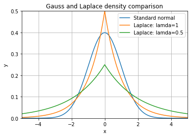

```python
# nothing to do here
import numpy as np
import matplotlib.pyplot as plt

x = np.linspace(-5,5,1000)
plt.plot(x, 1/(1 * np.sqrt(2 * np.pi)) *np.exp( - (x )**2 / (2 * 1**2) ), label='Standard normal')
plt.plot(x, 1*np.exp(-abs(x)*1)/2, label='Laplace: lamda=1')
plt.plot(x, 0.5*np.exp(-abs(x)*0.5)/2, label='Laplace: lamda=0.5')

plt.axis([-5, 5, 0, 0.5])
plt.grid()
plt.title('Gauss and Laplace density comparison')
plt.xlabel('x')
plt.ylabel('y')
plt.legend()
plt.show()
```

# Exercise B

In this exercise you are asked to apply ICA to estimate sources from noisy data. Imagine e.g. 4 instruments playing simultaneously and 4 microphones recording the mixed signals. ICA is used to recover the sources ie. what is played by each instrument. We will also compare this task with PCA and therby discover limitations of both methods. To do this, you should follow these steps:

### Question 4.6 (20 Points):

Let us first of all create the signals. To this end you should do the following tasks:

- Generate a time interval by creating sample data in the interval $[-1,1]$.
- Signals are usually given by periodic functions. To this end, create 4 different signals by evaluating the previously created time interval on 4 different periodic functions of your choice. Possible examples of periodic functions are trigonometric funtions like sine or cosine. For other commonly used ones in signal processing, consider e.g. https://docs.scipy.org/doc/scipy/reference/signal.html.
- Stash the four created signals together into one common array.
- Create a noisy version of this array by adding a e.g. Gaussian noise component of the same shape as the previously created signal array. Control the amount of noise by a scale parameter, for the purpose of a better visualization, this scaling parameter should not exceed $0.2$.
- **TODO:** Code

### Answer 4.6:

```python
from scipy import signal
from sklearn.decomposition import FastICA, PCA

# step 1
interval = np.linspace(-1, 1, 2001)

# step 2
s = np.sin(interval)
c = np.cos(interval)
t = np.tan(interval)
st = signal.sawtooth(interval)

# step 3
original = np.column_stack((s, c, t, st))

# step 4
def noise(mat, scale):
    return mat + np.random.normal(0, scale, mat.shape)

noisy = noise(original, .15)
```

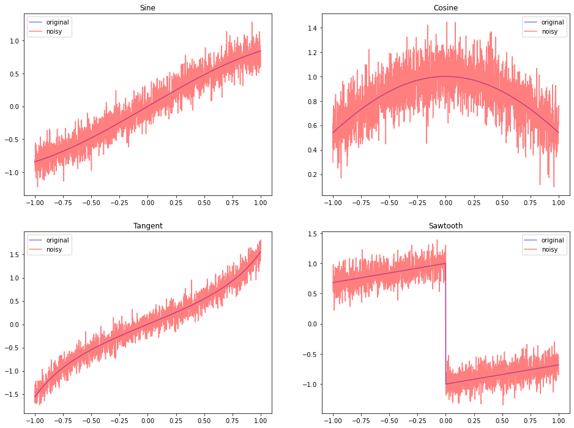

```python
def plot_periodical(matrices, labels, colors, titles=['Sine', 'Cosine', 'Tangent', 'Sawtooth']):
    _, ax = plt.subplots(nrows=2, ncols=2, figsize=(16, 12))

    for x in range(2):
        for y in range(2):
            for signal, label, color in zip(matrices, labels, colors):
                ax[x, y].plot(interval, signal[:, x*2 + y], alpha=0.5, color=color, label=label)
            ax[x, y].set_title(titles[x*2 + y])
            ax[x, y].legend()
    plt.show()

plot_periodical([original, noisy], ['original', 'noisy'], ['blue', 'red'])
```

### Question 4.7 (20 Points):

Next we want to create a mixed signal by applying a mixing matrix to the previously created signal array. To this end you should:

- Standardize the original and the noisy signal arrays using np.std
- Create any invertible $4\times4$ matrix.
- Multiply the previously created original and noisy signal arrays with the mixing matrix and store the resulting arrays.
- Finally plot the standardized, the mixed, the standardized noisy and the mixed noisy signal array. In each plot obviously four different signal graphs should be visible(as you previously were asked to create 4 different signals that should be stored in the array ;))
- **TODO:** Code

### Answer 4.7:

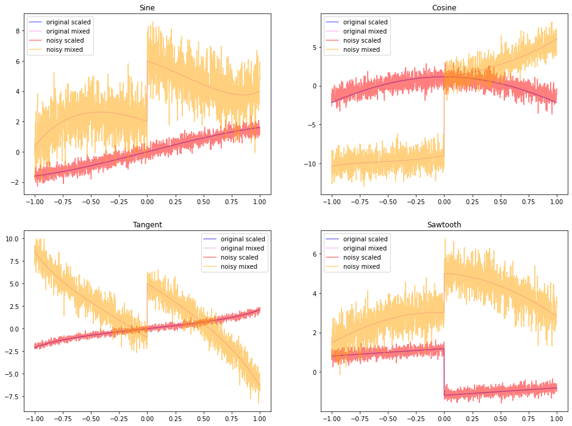

```python
# step 1
def scl(mat):
    return (mat - mat.mean(axis=0)) / np.std(mat, axis=0)

original_scld = scl(original)
noisy_scld = scl(noisy)

# step 2

# quick and dirty way to check if matrix is invertible
# det != 0 is unsafe because of floating point errors
while True:
    mixing_matrix = np.random.randint(-5, 5, (4, 4))
    try:
        np.linalg.inv(mixing_matrix)
        break
    except np.linalg.LinAlgError:
        print('Created not invertable matrix')

# step 3
original_mxd = original @ mixing_matrix
noisy_mxd = noisy @ mixing_matrix

# step 4
plot_periodical(
    [original_scld, original_mxd, noisy_scld, noisy_mxd],
    ['original scaled', 'original mixed', 'noisy scaled', 'noisy mixed'],
    ['blue', 'violet', 'red', 'orange'],
    ['Sine', 'Cosine', 'Tangent', 'Sawtooth']
)
```

### Question 4.8 (20 Points):

- Next apply ICA and PCA to the previously created mixed noisy signals. You are of course allowed to use the FastICA and the PCA commands from the sklearn-library(or any other pre-implemented algorithm for this purpose)
- Plot the mixed noisy signals, the original noisy signals, the ICA recovered signals and the PCA recovered signals.
- **TODO:** Code

### Answer 4.8:

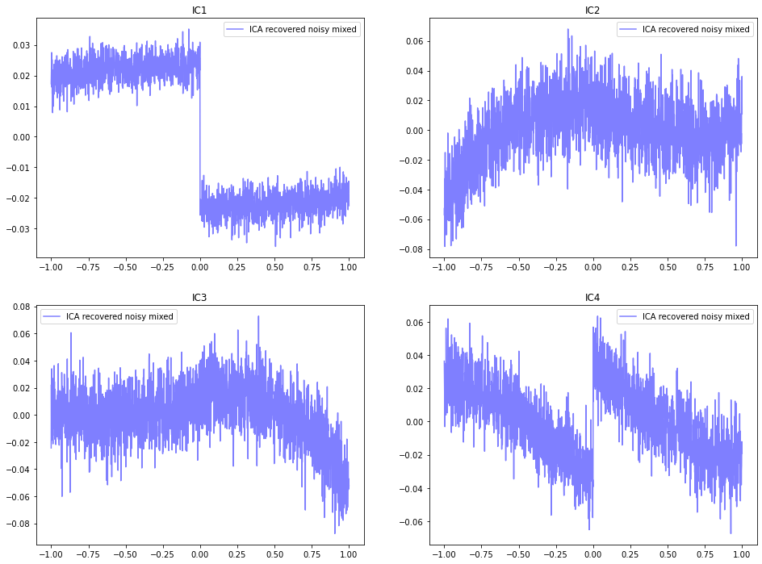

```python
# to ensure convergence
recovered_noisy = FastICA(max_iter=10000).fit_transform(noisy_mxd)
plot_periodical([recovered_noisy], ['ICA recovered noisy mixed'], ['blue'], [f'IC{i}' for i in range(1, 5)])
```

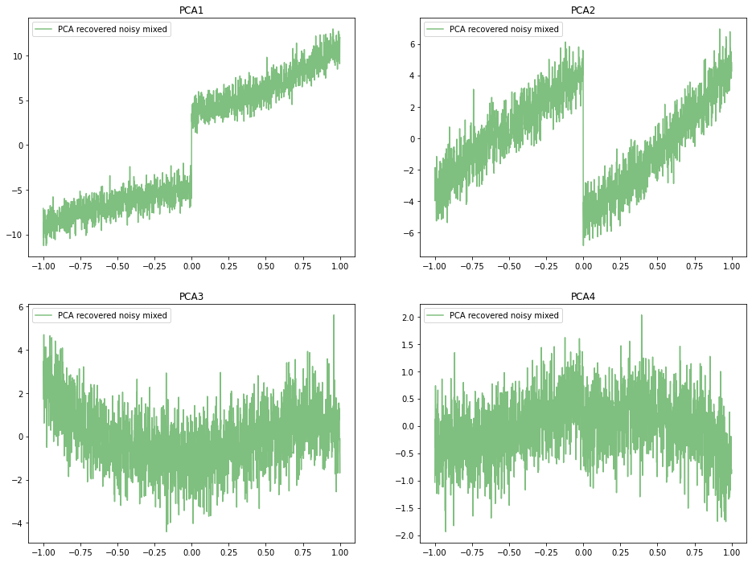

```python
recovered_noisy = PCA().fit_transform(noisy_mxd)
plot_periodical([recovered_noisy], ['PCA recovered noisy mixed'], ['green'], [f'PCA{i}' for i in range(1, 5)])
```

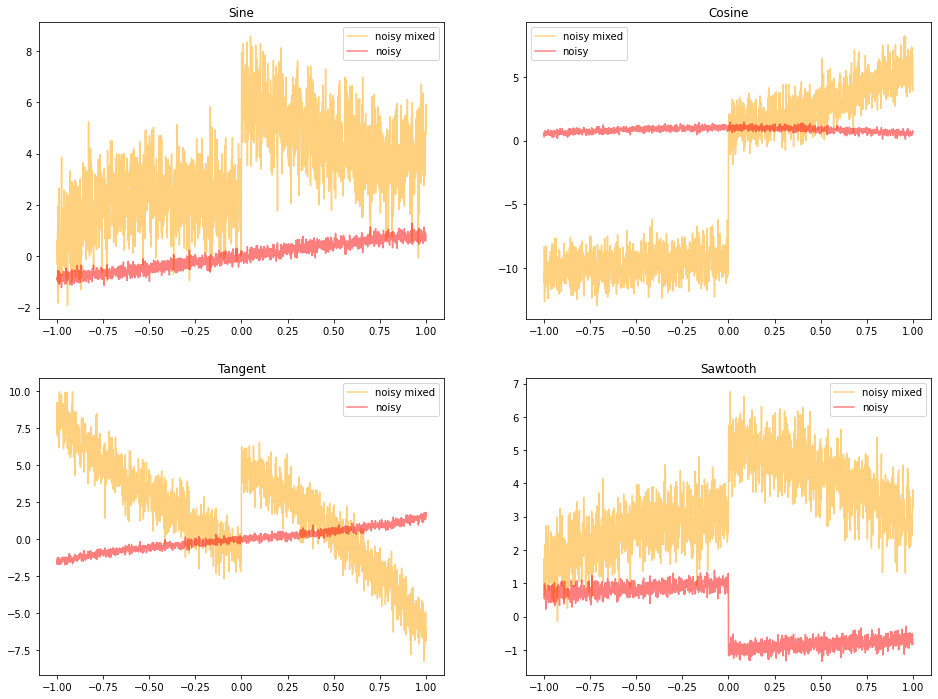

```python
plot_periodical([noisy_mxd, noisy], ['noisy mixed', 'noisy'], ['orange', 'red'])
```